# Hackathon Data Analysis

Add libraries, import and save files.

```r
members_trunc <- read_csv("./trunc_members.csv")
```

Wrange that data -convert numeric dates to actual date types

```r
# members_trunc <- members_trunc %>%
#   mutate(.,registration_init_time = as.Date(as.character(registration_init_time),"%Y%m%d"))
# transaction_trunc <- transaction_trunc %>%
#  mutate(.,transaction_date = as.Date(as.character(transaction_date),"%Y%m%d"))
#transaction_trunc <- transaction_trunc %>%
#  mutate(.,membership_expire_date = as.Date(as.character(membership_expire_date), format = "%Y %m %d"))
users_trunc <- users_trunc %>%
  mutate(.,date = as.Date(as.character(date),format = "%Y%m%d"))
```

Churn dataframe for QC

```r
print("Churn Dataframe")
```

```
[1] "Churn Dataframe"
```

```r
print(paste0("total entires: ", length(churn_trunc$is_churn)))
```

```
[1] "total entires: 20000"
```

```r
print(paste0("number unique msno: ",length(unique(churn_trunc$msno))))
```

```
[1] "number unique msno: 20000"
```

```r
print(paste0("total churns: ", sum(churn_trunc$is_churn)))
```

```
[1] "total churns: 1841"
```

```r
print(paste0("percentage churns: ", sum(churn_trunc$is_churn)/length(churn_trunc$is_churn)*100, "%"))
```

```
[1] "percentage churns: 9.205%"
```

Members dataframe for QC

```r
print("Members_trunc")
print(paste0("total entires: ", length(members_trunc$msno)))
print(paste0("number unique msno: ",length(unique(members_trunc$msno))))
print(paste0("number of cities: ", length((unique(members_trunc$city)))))
print(paste0("pop range in each city: ", members_trunc %>% group_by(., city) %>% count() %>%  range() ))
print(paste0("City 1 is probably a null when entering the form, or the first city the company started in."))
members_trunc %>% group_by(., city) %>% count()
print("see grouped_df for by city counts")
hist(members_trunc$city)
print("see histograme for by city counts")
print("see df and histogram for bd")
group_by(members_trunc, as.factor(members_trunc$bd)) %>% count()
hist(members_trunc$bd)
hist(members_trunc[which(members_trunc$bd>=5 & members_trunc$bd<100),]$bd)

print("obvious negaitve and extremely high (>100) can be ignored as truthful. ")
print("age=0 is roughly the same count as city, same member ids?")
print(paste0("gender breakdown(Female/male/NA: ",group_by(members_trunc,gender) %>% count())[2])
print("see datagrame of registration types")
members_trunc %>% group_by(., registered_via) %>% count()
print(paste0("Registration start data range",range(members_trunc$registration_init_time)))
```

[output not shown]

Explore usage dataset assemble dataframe with churn added

```r
users_seg <- merge(users_trunc,churn_trunc, by='msno', all = TRUE)
```

Missingness

```r
sum(is.na(users_seg$date))
```

```
[1] 0
```

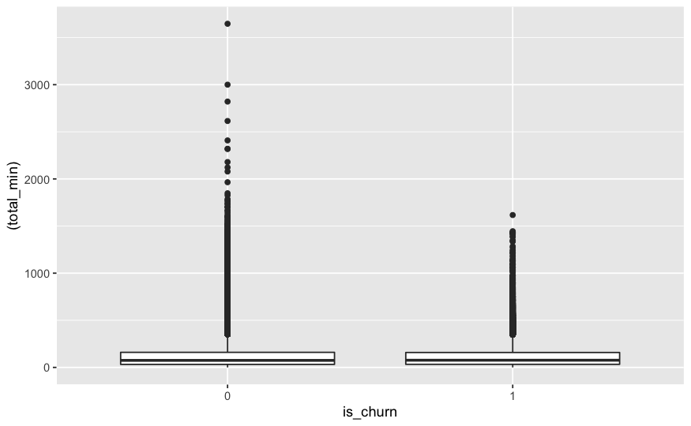

Visually, they look identical. There are some weird outliers, 2000 minutes of songs per day? Maybe the date feature is when the user started a session in rather than the strict date of play?

Statistically

```r
  var.test(user_seg_ttest$total_secs[user_seg_ttest$is_churn == 0], y = user_seg_ttest$total_secs[user_seg_ttest$is_churn == 1])
```

```
    F test to compare two variances

data:  user_seg_ttest$total_secs[user_seg_ttest$is_churn == 0] and user_seg_ttest$total_secs[user_seg_ttest$is_churn == 1]
F = 1.2285, num df = 254470, denom df = 22631, p-value < 2.2e-16
alternative hypothesis: true ratio of variances is not equal to 1
95 percent confidence interval:
 1.204986 1.252226
sample estimates:
ratio of variances
          1.228476
```

This also appear indistingusihable. Perhaps the pattern of usage, rather than the total will better characterize those who leave? Varience is unequal between the groups higher in the non-churn group.

How much data do we have for each user?

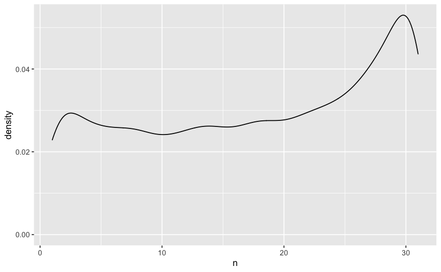

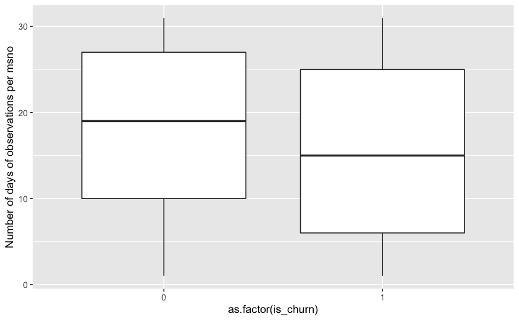

Again, there seems to be a slight difference between, perhaps the shape is different?

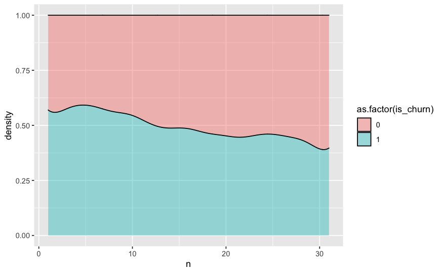

How do we characterize a day or activity? - engagement (number of interventions in playing) - choosiness (number of interventions before 75 or 98%) -percentage completed -average song length (feels weak) -date played? How do we characterize multiple days? How do we characterize a user?

Ideas - how does user behavior and likelihood to stay interact? - high intervention versus low intervention in song choice - city by city usage patterns? - are payment methods more likely to churn than others? - how are the people that leave? –what does usage look like? –what payment plans, information?

Price per day of plan:

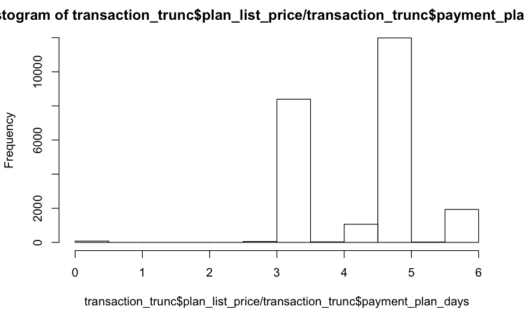

Seconds per month by user

```r
#length(unique(users_seg$msno)) 15457 if 20k drop NA



user_activity <- users_seg %>%
  group_by(., msno) %>%
  summarise(., num_active_days = length(unique(date)), num_seconds = sum(total_secs), is_churn = as.factor(mean(is_churn)))
length(unique(user_activity$msno))
```

```
[1] 15457
```

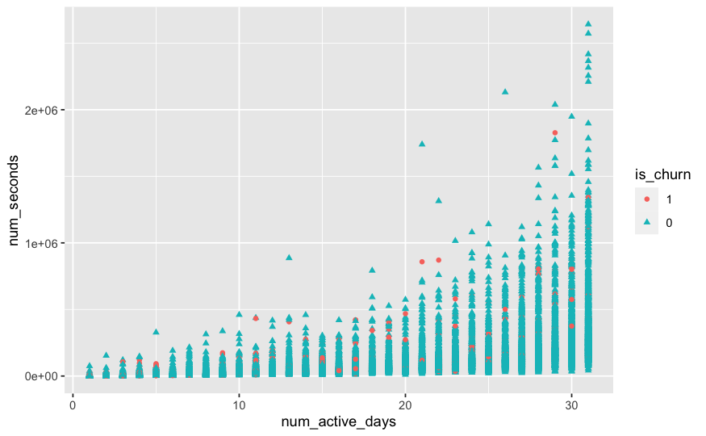

```r
user_activity %>%
  ggplot(., aes(x = num_active_days, y = num_seconds)) +
  geom_point(aes(shape = is_churn,color=is_churn,))
```

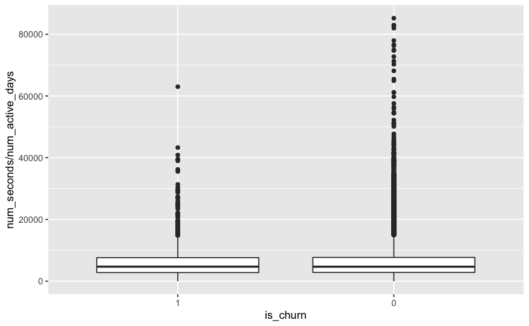

```r
# user_activity %>%
#   ggplot(., aes(x = is_churn, y = num_seconds)) +
#   geom_boxplot()
#
# user_activity %>%
#   ggplot(., aes(x = is_churn, y = num_active_days)) +
#   geom_boxplot()

user_activity %>%
  ggplot(., aes(x = is_churn, y = num_seconds /num_active_days)) +
  geom_boxplot()
```

Not much visually different, churners seem to blend in with regular users

Subscription length

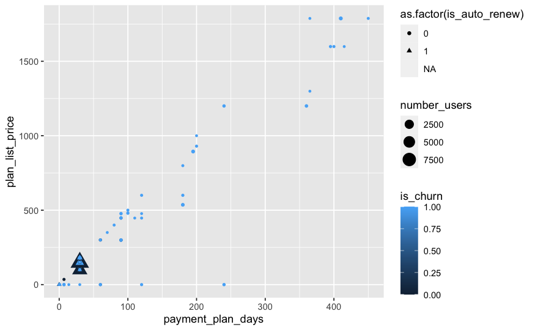

```r
T_and_M %>%
  group_by(., payment_plan_days, plan_list_price, is_churn, is_auto_renew) %>%  #payment plan days, list price, churn
  summarise(., number_users = n()) %>%
  mutate(., unq_ID = as.character(paste(payment_plan_days, plan_list_price, sep = "_"))) %>%
  #           0 = stayed,
  #           1 = left,
  #           total_user = sum(stayed, left)) %>%
  ggplot(., aes(x=payment_plan_days, y = plan_list_price, group = is_churn,color = is_churn, )) +
    geom_point( aes(size = number_users, shape=as.factor(is_auto_renew))  )
```

CHurn seems to be distributed evenly acorss length of subscription.

Feature engineering: These are some “listening session features” I came up with, the ones with proxy are to try and model variables in the literature. Average time at skip = weighted average of columns using the center point of the categories. (Num_25 = 0.1, num_50 = 0.375, num_75 = 0.625, num_985 = 0.8675, num_100 = 1) <25% and 100 are weighted differently to “pull” in a direction. Percent early skips = Num_25 + Num_50 / total skips Engagement = total skips / time played Range_proxy = unique songs / early skips Search_proxy = early skips / time (lots of skips for the amount listened) (percentage early skips versus total skips?) Tilt_proxy = total skips (same as engagement?)

unique listens? total songs -

skips per full song

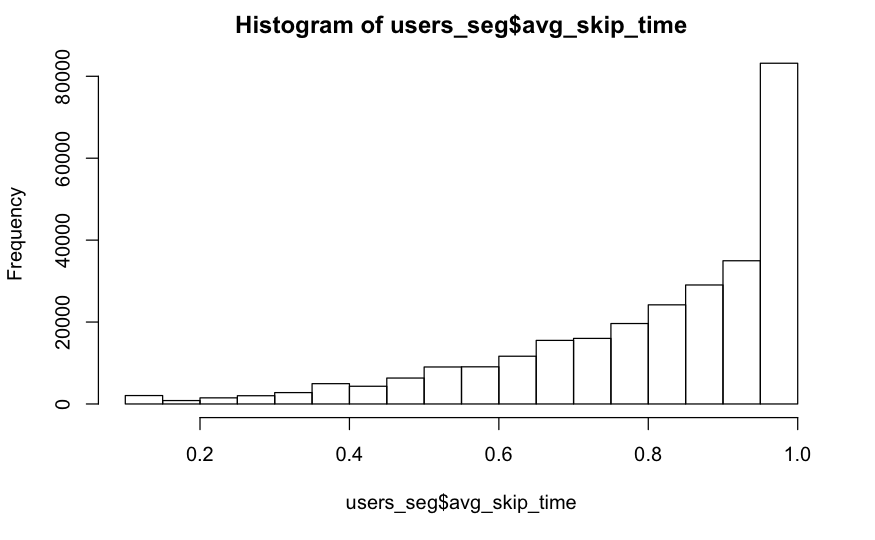

```r
users_seg <- users_seg %>%
  rowwise() %>%
  mutate(.,
        total_skips = sum(num_25, num_50,num_75, num_985, num_100),
        avg_skip_time = (num_25*0.1 + num_50*0.375 +
                           num_75*0.625 + num_985*0.8675 +
                           num_100*1 )/ total_skips,
        early_skips = sum(c(num_25, num_50)),
        late_skips = sum(c(num_985, num_100)),
        percent_early_skips = early_skips / total_skips,
        skips_per_secs = total_skips / total_secs,
        range_proxy = ifelse(early_skips != 0, num_unq / early_skips, 4000),
        serach_proxy = early_skips / total_secs,
        tilt_proxy = total_skips,
        #final version?
        plays_per_unique = total_skips / num_unq,
        skips_per_full = ifelse(late_skips != 0, early_skips/ late_skips, 150),
        outer_skips = sum(c(num_25,num_100))
        )

hist(users_seg$avg_skip_time)
```

```r
range(users_seg$avg_skip_time)
```

```
[1] 0.1 1.0
```

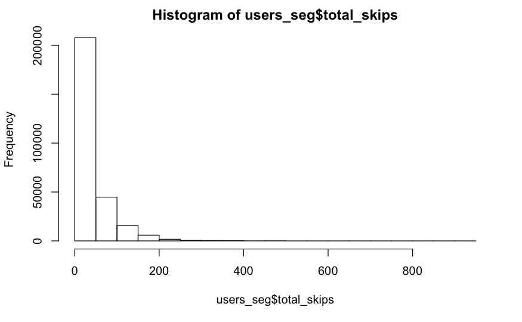

```r
hist(users_seg$total_skips)
```

```r
users_seg %>%
  filter(., avg_skip_time >0.9)
```

| msno | date | num_25 | num_50 | num_75 | num_985 | num_100 | num_unq | total_secs | is_churn | total_skips | avg_skip_time | early_skips | percent_early_skips | skips_per_secs | range_proxy | serach_proxy | tilt_proxy | late_skips | plays_per_unique | skips_per_full | outer_skips |
| --- | --- | --- | --- | --- | --- | --- | --- | --- | --- | --- | --- | --- | --- | --- | --- | --- | --- | --- | --- | --- | --- |
| //aWvY7Y+dy+OCzivW4e/ojzfGRRv4QeN3E4gfBojVI= | 2017-03-16 | 1 | 0 | 0 | 3 | 13 | 15 | 3820.727 | 1 | 17 | 0.9236765 | 1 | 0.058823529 | 0.004449415 | 15.000000 | 2.617303e-04 | 17 | 16 | 1.133333 | 0.062500000 | 14 |
| //aWvY7Y+dy+OCzivW4e/ojzfGRRv4QeN3E4gfBojVI= | 2017-03-23 | 0 | 0 | 0 | 0 | 1 | 1 | 209.000 | 1 | 1 | 1.0000000 | 0 | 0.000000000 | 0.004784689 | 4000.000000 | 0.000000e+00 | 1 | 1 | 1.000000 | 0.000000000 | 1 |
| //aWvY7Y+dy+OCzivW4e/ojzfGRRv4QeN3E4gfBojVI= | 2017-03-13 | 0 | 0 | 0 | 1 | 8 | 8 | 2223.346 | 1 | 9 | 0.9852778 | 0 | 0.000000000 | 0.004047953 | 4000.000000 | 0.000000e+00 | 9 | 9 | 1.125000 | 0.000000000 | 8 |
| //LE/G/D+EVR5MsyZddzVKtNBzhR4T7MWpSLEOpP/Uo= | 2017-03-11 | 0 | 0 | 0 | 1 | 36 | 21 | 10298.382 | 0 | 37 | 0.9964189 | 0 | 0.000000000 | 0.003592797 | 4000.000000 | 0.000000e+00 | 37 | 37 | 1.761905 | 0.000000000 | 36 |
| //LE/G/D+EVR5MsyZddzVKtNBzhR4T7MWpSLEOpP/Uo= | 2017-03-18 | 0 | 0 | 0 | 0 | 58 | 2 | 16783.098 | 0 | 58 | 1.0000000 | 0 | 0.000000000 | 0.003455858 | 4000.000000 | 0.000000e+00 | 58 | 58 | 29.000000 | 0.000000000 | 58 |
| //LE/G/D+EVR5MsyZddzVKtNBzhR4T7MWpSLEOpP/Uo= | 2017-03-13 | 0 | 0 | 0 | 0 | 5 | 2 | 1410.429 | 0 | 5 | 1.0000000 | 0 | 0.000000000 | 0.003545021 | 4000.000000 | 0.000000e+00 | 5 | 5 | 2.500000 | 0.000000000 | 5 |
| //LE/G/D+EVR5MsyZddzVKtNBzhR4T7MWpSLEOpP/Uo= | 2017-03-19 | 1 | 0 | 0 | 0 | 38 | 2 | 10930.861 | 0 | 39 | 0.9769231 | 1 | 0.025641026 | 0.003567880 | 2.000000 | 9.148410e-05 | 39 | 38 | 19.500000 | 0.026315789 | 39 |
| //LE/G/D+EVR5MsyZddzVKtNBzhR4T7MWpSLEOpP/Uo= | 2017-03-10 | 0 | 0 | 0 | 0 | 1 | 1 | 255.164 | 0 | 1 | 1.0000000 | 0 | 0.000000000 | 0.003919048 | 4000.000000 | 0.000000e+00 | 1 | 1 | 1.000000 | 0.000000000 | 1 |
| //LE/G/D+EVR5MsyZddzVKtNBzhR4T7MWpSLEOpP/Uo= | 2017-03-16 | 1 | 1 | 0 | 0 | 24 | 2 | 6065.554 | 0 | 26 | 0.9413462 | 2 | 0.076923077 | 0.004286500 | 1.000000 | 3.297308e-04 | 26 | 24 | 13.000000 | 0.083333333 | 25 |
| //LE/G/D+EVR5MsyZddzVKtNBzhR4T7MWpSLEOpP/Uo= | 2017-03-23 | 0 | 0 | 0 | 0 | 8 | 2 | 2386.440 | 0 | 8 | 1.0000000 | 0 | 0.000000000 | 0.003352274 | 4000.000000 | 0.000000e+00 | 8 | 8 | 4.000000 | 0.000000000 | 8 |

[output cut: 990 more lines]

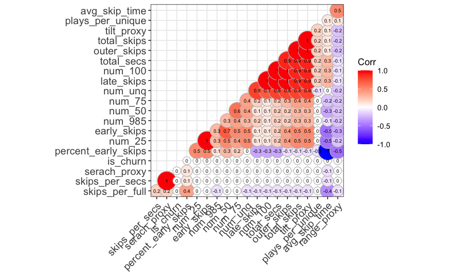

```r
correl <- round(cor(select(users_seg, -c(msno,date))),1)

ggcorrplot(correl, hc.order = T,
           type = "lower",
           lab = T,
           lab_size = 2,
           method="circle",
           ggtheme = theme_bw)
```

Repeat but grouping by user before feature generation

```r
agg_users <- users_seg %>%
  group_by(., msno) %>%
  summarise(., days_played = n(),
            num_25=sum(num_25),
            num_50=sum(num_50),
            num_75=sum(num_75),
            num_985=sum(num_985),
            num_100=sum(num_100),
            num_unq=sum(num_unq),
            total_secs=sum(total_secs),
            is_churn=mean(is_churn)
            )
length(unique(agg_users$msno)) #15457
```

```
[1] 15457
```

```r
library(tidyverse)
library(ggplot2)

agg_users <- agg_users %>%
 rowwise() %>%
  mutate(.,
        total_skips = sum(num_25, num_50,num_75, num_985, num_100),
        avg_skip_time = (num_25*0.1 + num_50*0.375 +
                           num_75*0.625 + num_985*0.8675 +
                           num_100*1 )/ total_skips,
        early_skips = sum(c(num_25, num_50)),
        late_skips = sum(c(num_985, num_100)),
        percent_early_skips = early_skips / total_skips,
        skips_per_secs = total_skips / total_secs,
        range_proxy = ifelse(early_skips != 0, num_unq / early_skips, 4000),
        serach_proxy = early_skips / total_secs,
        tilt_proxy = total_skips,
        #final version?
        plays_per_unique = total_skips / num_unq,
        skips_per_full = ifelse(late_skips != 0, early_skips/ late_skips, 150),
        outer_skips = sum(c(num_25,num_100))
        )
```

range proxy, 27k at most (unique / early skips) set to 3 or 4k. (no early skips) Most are low listeners or late skipers.

skips per full: highest value is 80 the rest are infinity. set to 150.

Data exploration

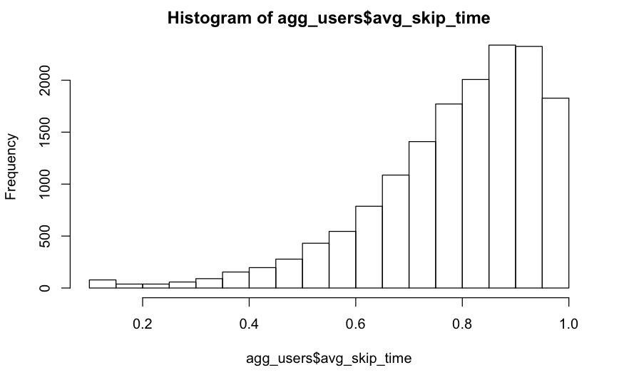

```r
hist(agg_users$avg_skip_time)
```

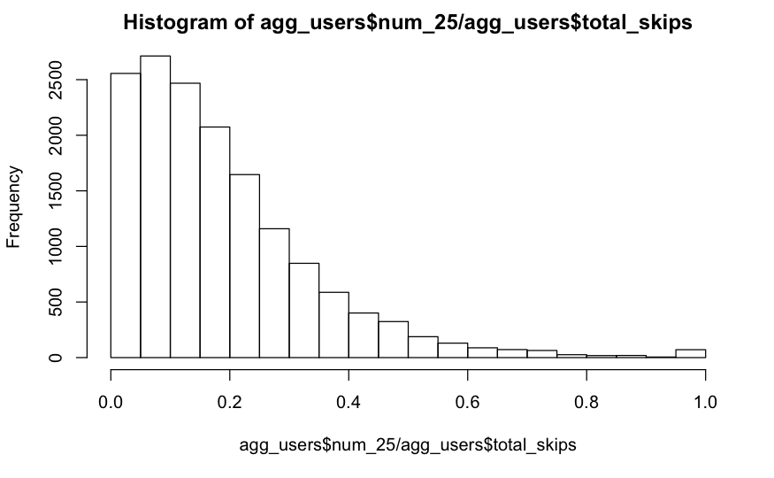

```r
hist(agg_users$num_25 / agg_users$total_skips)
```

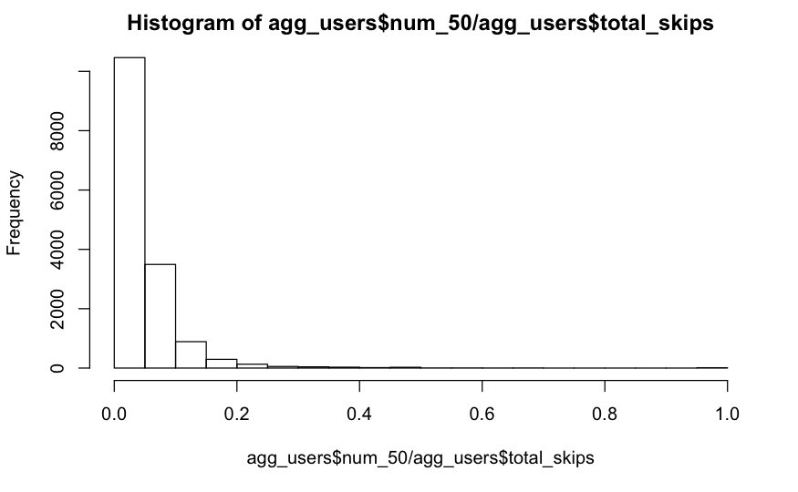

```r
hist(agg_users$num_50 / agg_users$total_skips)
```

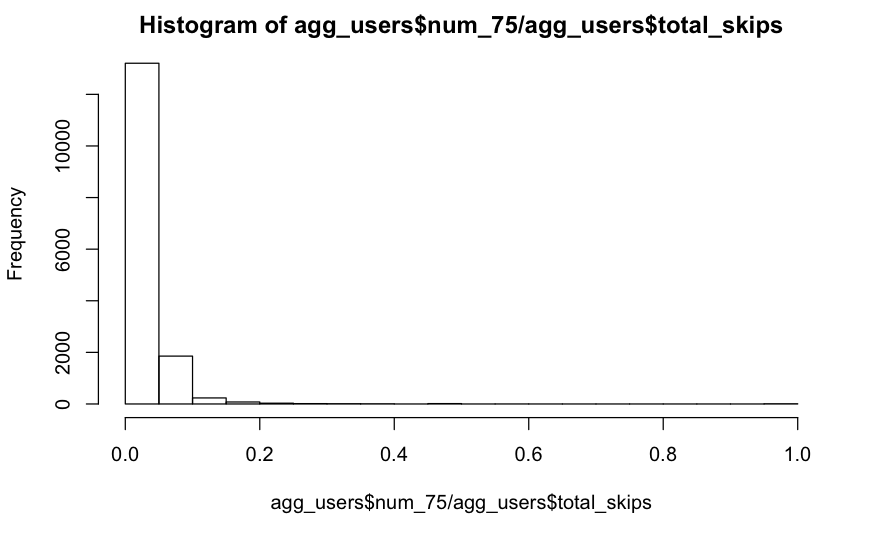

```r
hist(agg_users$num_75 / agg_users$total_skips)
```

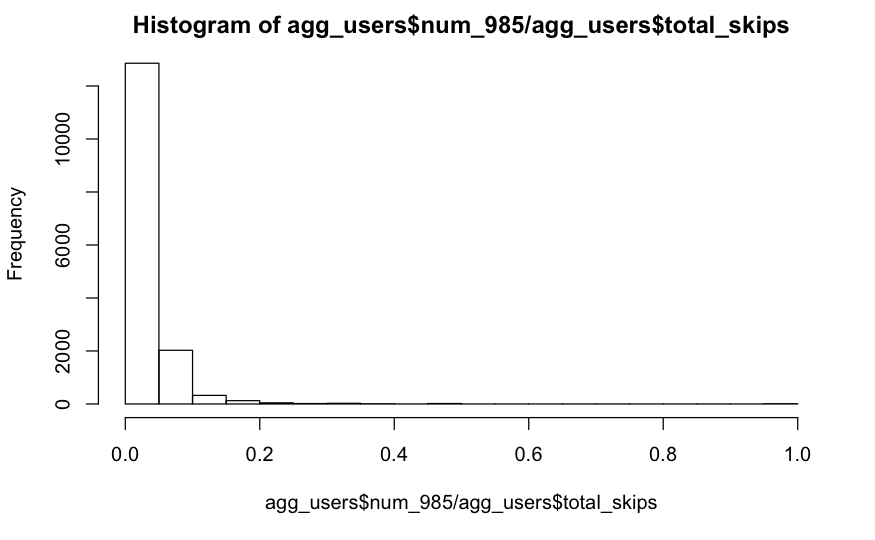

```r
hist(agg_users$num_985 / agg_users$total_skips)
```

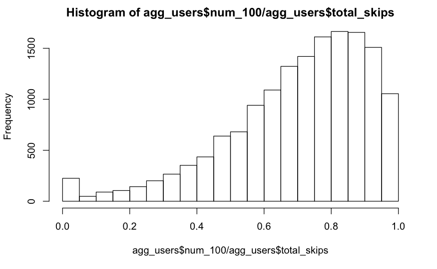

```r
hist(agg_users$num_100 / agg_users$total_skips)
```

more complicated

```r
agg_users %>%
  ggplot(., aes(x=avg_skip_time)) +
  geom_histogram()

agg_users %>%
  ggplot(., aes(x=total_skips, group= as.factor(is_churn), fill = as.factor(is_churn))) +
  geom_histogram(position = "stack")

agg_users %>%
  ggplot(., aes(x=total_skips, group= as.factor(is_churn), fill = as.factor(is_churn))) +
  geom_histogram(position = "fill")

#install.packages("ggcorrplot")
library(ggcorrplot)

correl_assembly <- agg_users %>%
  select(., -c(msno))

correl <- round(cor(select(agg_users, -msno)),1)

ggcorrplot(correl, hc.order = T,
           type = "lower",
           lab = T,
           lab_size = 2,
           method="circle",
           ggtheme = theme_bw)


#averg search time versus search proxies:

plot_avgskip_vs_skipPerFull <- agg_users %>%
  ggplot(., aes(x = avg_skip_time, y = skips_per_full, group = as.factor(is_churn))) +
  geom_point(aes(color = as.factor(is_churn)))

many_boxes <- agg_users %>%
  ggplot(., aes(as.factor(is_churn), )) +
  geom_boxplot()

for (thingy in colnames(select(agg_users, -msno))){
  plot_name <-ggplot(agg_users, aes(as.factor(is_churn), y = agg_users$thingy)) +
    geom_boxplot()
  print(plot_name)
}


ggplot(agg_users, aes(as.factor(is_churn), y = agg_users$days_played)) +
    geom_boxplot()
ggplot(agg_users, aes(as.factor(is_churn), y = agg_users$num_25)) +
    geom_boxplot()
ggplot(agg_users, aes(as.factor(is_churn), y = agg_users$num_50)) +
    geom_boxplot()
ggplot(agg_users, aes(as.factor(is_churn), y = agg_users$num_75)) +
    geom_boxplot()
ggplot(agg_users, aes(as.factor(is_churn), y = agg_users$num_985)) +
    geom_boxplot()
ggplot(agg_users, aes(as.factor(is_churn), y = agg_users$num_100)) +
    geom_boxplot()
ggplot(agg_users, aes(as.factor(is_churn), y = agg_users$num_unq)) +
    geom_boxplot()
ggplot(agg_users, aes(as.factor(is_churn), y = agg_users$total_secs)) +
    geom_boxplot()
ggplot(agg_users, aes(as.factor(is_churn), y = agg_users$is_churn)) +
    geom_boxplot()
ggplot(agg_users, aes(as.factor(is_churn), y = agg_users$total_skips)) +
    geom_boxplot()
ggplot(agg_users, aes(as.factor(is_churn), y = agg_users$avg_skip_time)) +
    geom_boxplot()
ggplot(agg_users, aes(as.factor(is_churn), y = agg_users$early_skips)) +
    geom_boxplot()
ggplot(agg_users, aes(as.factor(is_churn), y = agg_users$late_skips)) +
    geom_boxplot()
ggplot(agg_users, aes(as.factor(is_churn), y = agg_users$percent_early_skips)) +
    geom_boxplot()
ggplot(agg_users, aes(as.factor(is_churn), y = agg_users$skips_per_secs)) +
    geom_boxplot()
ggplot(agg_users, aes(as.factor(is_churn), y = agg_users$range_proxy)) +
    geom_boxplot()
ggplot(agg_users, aes(as.factor(is_churn), y = agg_users$serach_proxy)) +
    geom_boxplot()
ggplot(agg_users, aes(as.factor(is_churn), y = agg_users$tilt_proxy)) +
    geom_boxplot()
ggplot(agg_users, aes(as.factor(is_churn), y = agg_users$plays_per_unique)) +
    geom_boxplot()
ggplot(agg_users, aes(as.factor(is_churn), y = agg_users$skips_per_full)) +
    geom_boxplot()
ggplot(agg_users, aes(as.factor(is_churn), y = agg_users$outer_skips)) +
    geom_boxplot()
```

[output not shown]

```r
agg_users %>%
  mutate(is_churn = recode(is_churn, '0'="Retained","1"="Lost")) %>%
  ggplot(., aes(x=days_played, group = is_churn,fill = is_churn)) +
  geom_histogram(position = "fill") +
  ylab("Percent Churn Decision") +
  xlab("Number of Days With Sessions") +
  ggtitle("Percentage churn", )

#things that correlate with days played:
# -0.2 percent early skips
# -0.2 skips per full
# -0.1 is churn
# 0.2 avg_skip_time
# -0.2 range proxy (unique / early skip)

correl <- round(cor(select(agg_users, -msno)),1)

ggcorrplot(correl, hc.order = T,
           type = "full",
           lab = T,
           lab_size = 2,
           method="square",
           ggtheme = theme_bw)



#percent early skips and total seconds are inversely correlated
#test longer accounts versus listening behavior
```

[output not shown]

#### 30 day flag plot

```r
ggsave("users by plan length and auto renew", plot = selected_plot, device = "png")
```

```r
 plan_df %>%
  filter(., is_auto_renew == 1 & day30_flag == "30 Day Plan") %>%
  group_by(., plan_list_price) %>%
  summarise(., count = n(), percentage = count / sum(count)) %>%
  ungroup(.) %>%
  mutate(.,percentage = (count / sum(count))*100) %>%
  mutate(., plan_list_price = paste0("$",as.factor(plan_list_price))) %>%
  mutate(., plan_list_price = factor(plan_list_price, levels = c("$99","$100","$119","$120","$129", "$131","$149", "$180")))
```

| plan_list_price | count | percentage |
| --- | --- | --- |
| $99 | 5988 | 31.329461623 |
| $100 | 585 | 3.060743996 |
| $119 | 11 | 0.057552451 |
| $120 | 6 | 0.031392246 |
| $129 | 883 | 4.619892220 |
| $131 | 1 | 0.005232041 |
| $149 | 10288 | 53.827238006 |
| $180 | 1351 | 7.068487417 |

```r
plan_df %>%
  filter(., is_auto_renew == 1 & day30_flag == "30 Day Plan") %>%
  group_by(., plan_list_price, is_churn) %>%
  summarise(., count = n()) %>%
  mutate(., is_churn = recode(is_churn, '0'="Stayed", '1'="Churn")) %>%
  spread(., is_churn, count) %>%
  mutate(., percentage_churn = Churn /(Stayed + Churn))
```

| plan_list_price | Churn | Stayed | percentage_churn |
| --- | --- | --- | --- |
| 99 | 281 | 5707 | 0.04692719 |
| 100 | 15 | 570 | 0.02564103 |
| 119 | 6 | 5 | 0.54545455 |
| 120 | 2 | 4 | 0.33333333 |
| 129 | 133 | 750 | 0.15062288 |
| 131 | NA | 1 | NA |
| 149 | 913 | 9375 | 0.08874417 |
| 180 | 129 | 1222 | 0.09548483 |

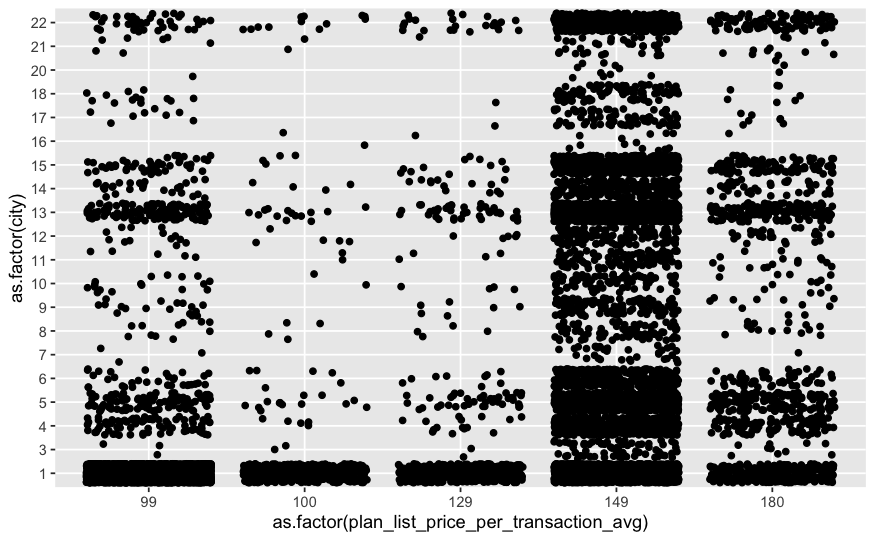

final graphs

```r
plans_user %>%
  nrow()
```

```
[1] 12957
```

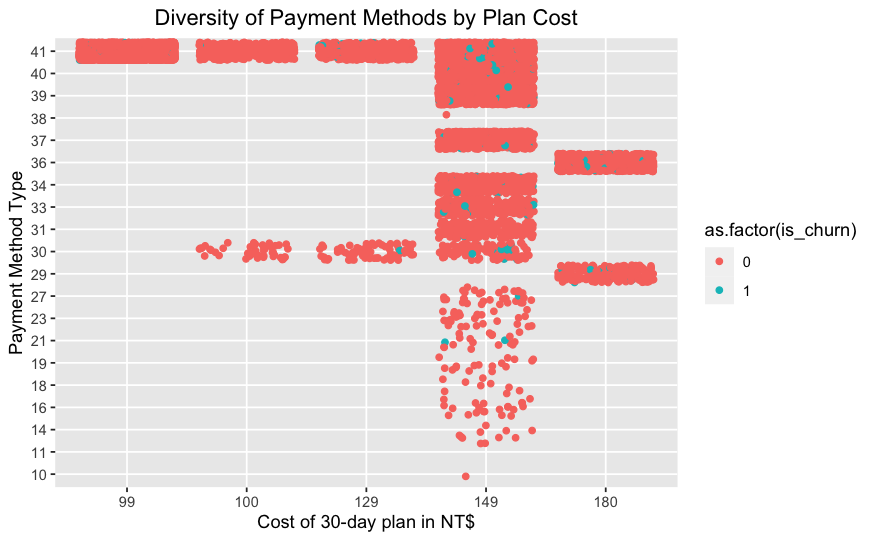

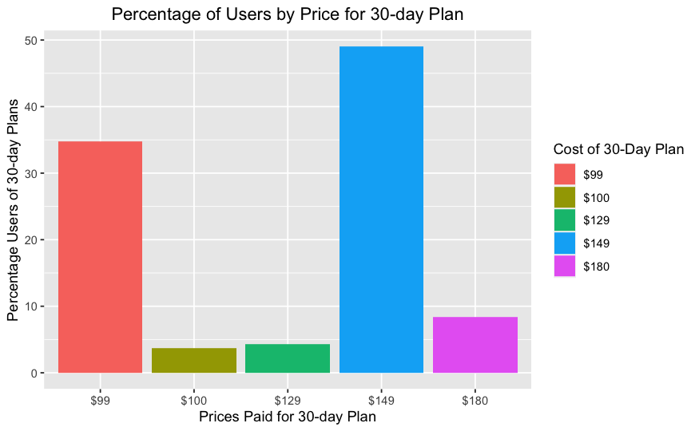

```r
plans_user %>%
  group_by(., plan_list_price_per_transaction_avg) %>%
  summarise(., count= n(), percentage = count / sum(count)) %>%
  ungroup(.) %>%
  mutate(.,percentage = (count / sum(count))*100) %>%
  mutate(., plan_list_price_per_transaction_avg = paste0("$",as.factor(plan_list_price_per_transaction_avg))) %>%
  mutate(., plan_list_price_per_transaction_avg = factor(plan_list_price_per_transaction_avg, levels = c("$99","$100","$129","$149", "$180"))) %>%
  ggplot(., aes(x=as.factor(plan_list_price_per_transaction_avg), y = percentage, fill = plan_list_price_per_transaction_avg)) +
  geom_bar(stat = "identity" ) +
  labs(title = "Percentage of Users by Price for 30-day Plan",
       x = "Prices Paid for 30-day Plan",
       y = "Percentage Users of 30-day Plans") +
  theme(plot.title = element_text(hjust = 0.5)) +
  guides(fill=guide_legend(title = "Cost of 30-Day Plan"))
```